# Session 5 — Choosing, Comparing and Reporting

Ordinal vs multinomial · probability plots · classification accuracy · tables · checklist · Lab 5

Community Medicine Workshop

## Where we are

- Sessions 1-4: ordered and nominal outcomes, the assumption, the models
- Today: **choose** between them, **show** the results, **report**
- By the end you can:
  - justify **ordinal vs multinomial**
  - plot **predicted probabilities**
  - judge a model without relying on **accuracy**
  - write the **methods and results**

# Topic 1 — Ordinal or multinomial?

## A decision

| Question | Answer | Model |
| --- | --- | --- |
| Is there a **meaningful order**? | No | **Multinomial** logistic |
|  | Yes | **Ordinal** logistic (proportional odds) |
| Does **proportional odds** hold (Brant, cut-point ORs)? | Yes | one OR per predictor |
|  | One or a few predictors fail | **Partial** proportional odds |
|  | Many fail | **Multinomial** |

## The same data, two models

```r
a_ord <- MASS::polr(anaemia ~ wealth + tribal, data = mat, Hess = TRUE)
a_mn <- nnet::multinom(factor(anaemia, ordered = FALSE) ~ wealth + tribal, data = mat, trace = FALSE)
c(ordinal = AIC(a_ord), multinomial = AIC(a_mn)) |> round(0)
```

```
    ordinal multinomial
       3200        3170
```

The multinomial model has the **lower AIC** because it frees the tribal effect at each cut-point; it also needs **many more parameters** (9 vs 5). When proportional odds **holds**, the ordinal model is simpler and **more powerful**. When it fails and cannot be relaxed, **multinomial is the safe fallback**.

# Topic 2 — Showing results

## Probabilities against a predictor

```r
m_ord <- MASS::polr(anaemia ~ wealth + education + bmi + anc_visits + parity + age + tribal + residence, data = mat, Hess = TRUE)
nd <- data.frame(wealth = 1:5, education = factor("Primary", levels = levels(mat$education)), bmi = 20.5, anc_visits = 3, parity = 2, age = 27, tribal = factor("No", levels = c("No", "Yes")), residence = factor("Rural", levels = c("Urban", "Rural")))
cbind(wealth = 1:5, as.data.frame(predict(m_ord, newdata = nd, type = "probs"))) |> pivot_longer(-wealth, names_to = "anaemia", values_to = "probability") |>
  mutate(anaemia = factor(anaemia, levels = levels(mat$anaemia))) |>
  ggplot(aes(wealth, probability, colour = anaemia)) + geom_line(linewidth = 1.2) + labs(x = "Wealth quintile", y = "Predicted probability", colour = NULL)
```

## Probabilities against a predictor

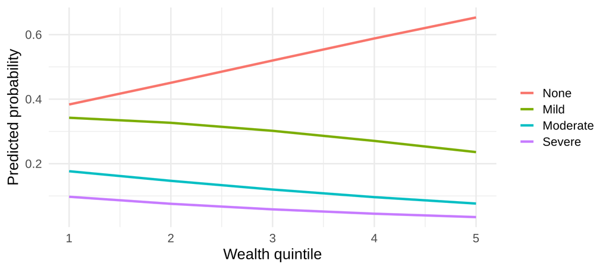

## Accuracy is a weak summary

```r
mat$delivery <- relevel(mat$delivery, ref = "Home")
mn <- nnet::multinom(delivery ~ wealth + education + anc_visits + residence + tribal, data = mat, trace = FALSE)
c(model = mean(predict(mn) == mat$delivery), always_most_common = max(prop.table(table(mat$delivery)))) |> round(2)
```

```
             model always_most_common
              0.48               0.32
```

The model is right about **48%** of the time vs **32%** for always guessing the most common place. Covariates **shift probabilities** but **cannot predict an individual’s choice**; accuracy ignores the probabilities. Use **predicted probabilities**, **AIC** or **log-likelihood**, and, if prediction is the aim, **calibration** and **proper scoring rules**.

# Topic 3 — Reporting

## Wording

**Ordinal:** “In a proportional-odds model adjusted for education, BMI, antenatal visits, parity, age, tribal group and residence, each higher wealth quintile was associated with **24% lower odds** of being in a worse anaemia category (OR 0.76, 95% CI …). The assumption held for all predictors except tribal group, so its effect is reported separately at each cut-point.”

**Multinomial:** “Compared with home delivery, each wealth quintile increased the **relative risk** of delivering in a private hospital 2.8-fold (RRR 2.76, 95% CI …).”

## Reporting checklist

1. **Outcome** categories, order, **counts**; **reference** category (nominal)
2. **Model** and **why** (ordered or not); **software** (`MASS`, `nnet`, `ordinal`)
3. **Odds ratios** (ordinal) or **relative risk ratios** (multinomial) with **95% CI**; adjustment set
4. **Assumption check** (Brant, cut-specific ORs) and what you did
5. **Predicted probabilities** for key profiles
6. **Limitations**: sparse categories, many parameters, association not cause, self-reported outcomes

## 🔧 Switch to R — Lab 5

**File:** `ordinal-workshop/labs/lab5_report.R`

- ordinal vs multinomial fitted to the same ordered outcome
- probability tables and a plot
- accuracy against guessing; a publication table

**Time:** 30 minutes · answer the Q questions in the comments

## Self-check quiz (1/5)

When is the multinomial model a good choice for an ordered outcome?

- The sample of women is very small for a model with many parameters
- All the predictors in the model are binary variables only
- Proportional odds fails for many predictors and cannot be relaxed
- The outcome has three ordered categories in the data set

## Self-check quiz (2/5)

The multinomial model classifies 48% of women correctly and always guessing the most common place gives 32%. What is the best conclusion?

- The model is excellent, since it beats guessing the most common place
- Covariates shift probabilities, but accuracy is a weak summary
- The model has failed and should be rejected for this use
- The two numbers cannot be compared with each other in any way

## Self-check quiz (3/5)

Why plot predicted probabilities against a predictor such as wealth?

- They give the p-value of the Brant test for the predictor shown
- They replace the need for odds ratios in any paper that is written
- They show how each category’s probability changes with it
- They prove that the effect of the predictor is a causal one

## Self-check quiz (4/5)

Which sentence is the best way to report an ordinal result when the assumption holds?

- Each higher quintile lowers the anaemia grade by 0.76 of one whole category
- Wealthy women have 76% of the anaemia that is found in poor women
- Wealth had a significant effect on anaemia because the p-value was small
- Each higher quintile went with 24% lower odds of a worse category (OR 0.76)

## Self-check quiz (5/5)

What belongs in the limitations of a categorical-outcome analysis?

- Sparse categories, many parameters, and association not being cause
- The fact that the outcome has more than two categories to model
- That odds ratios cannot be reported when there are many categories
- That the software used for the analysis was written in the R language

## Score and take-home

**Your score:**

- Ordered and the assumption holds: **ordinal**; fails for one or two: **partial**; many or no order: **multinomial**
- Show **predicted probabilities** and plots, not only odds ratios
- Do not judge by **classification accuracy**
- Report **categories, reference, model, ORs/RRRs with CI, assumption check, limitations**

**Next:** The cheat sheet and the Dungeons & Dataframes ordinal and nominal world (coming)